# DSAN 6650 Fall 2025

Homework 1

Author

Affiliation

CJ Jones

Georgetown University

### 0.1 Submitter: CJ Jones

## 1 Part 0: Package Reload and Imports

## 2 Part 1: Boat in a Simple GridWorld

The simple boat grid world problem involves navigating a boat across a grid like ocean, where the agent must reach a goal by choosing from the actions of move left or right while contending with environmental dynamics of wind. The environment assigns rewards or penalties based on the agent’s movements and outcomes, requiring the agent to learn an optimal policy to maximize its total rewards while overcoming stochastic transitions.

### 2.1 Part 1.1: Setup and Register Environments

First register the environments that will be created for the different RL training algorithms. Then pass a quick check to make sure that the environment created to model the boat world problem conforms with standard gymnasium class requirements to ensure proper updating and environment steps.

```
Wind direction array [1 0] with action [-1  0] total move [0 0] old location [1 0] and new location [1 0]
Wind direction array [1 0] with action [1 0] total move [1 0] old location [0 0] and new location [1 0]
Wind direction array [1 0] with action [1 0] total move [1 0] old location [0 0] and new location [1 0]
Environment passes all checks!
```

### 2.2 Part 1.2: Visualize the boat (a blue dot) moving through the environments with random actions

Here with a completely random policy of choosing actions we can visualize the agent moving through the environment. In this demo only 15 steps are showing so it is difficult to get a total sense of environmental conditions, in later training steps will be simulated tens of thousands of times.

```
Step 0: Action Taken: 1, Observation: {'agent': array([0, 0], dtype=int32)}, Reward: 0
Step 1: Action Taken: 0, Observation: {'agent': array([1, 0], dtype=int32)}, Reward: 2
Step 2: Action Taken: 1, Observation: {'agent': array([0, 0], dtype=int32)}, Reward: 2
Step 3: Action Taken: 1, Observation: {'agent': array([0, 0], dtype=int32)}, Reward: 0
Step 4: Action Taken: 1, Observation: {'agent': array([0, 0], dtype=int32)}, Reward: 1
Step 5: Action Taken: 1, Observation: {'agent': array([0, 0], dtype=int32)}, Reward: 1
Step 6: Action Taken: 0, Observation: {'agent': array([0, 0], dtype=int32)}, Reward: 1
Step 7: Action Taken: 1, Observation: {'agent': array([0, 0], dtype=int32)}, Reward: 0
Step 8: Action Taken: 1, Observation: {'agent': array([0, 0], dtype=int32)}, Reward: 1
Step 9: Action Taken: 0, Observation: {'agent': array([1, 0], dtype=int32)}, Reward: 2
Step 10: Action Taken: 0, Observation: {'agent': array([1, 0], dtype=int32)}, Reward: 4
Step 11: Action Taken: 1, Observation: {'agent': array([1, 0], dtype=int32)}, Reward: 3
Step 12: Action Taken: 1, Observation: {'agent': array([0, 0], dtype=int32)}, Reward: 2
Step 13: Action Taken: 1, Observation: {'agent': array([0, 0], dtype=int32)}, Reward: 0
Step 14: Action Taken: 0, Observation: {'agent': array([0, 0], dtype=int32)}, Reward: 1
```

### 2.3 Part 1.3: Simulating the Boat World with Dynamic Programming

#### 2.3.1 Dynamic Programming Intro

In the Dynamic Programming setup for the Boat’s simple gridworld, the goal is to generate an approximation of the probability transition matrix by running steps of the environment and then counting the observed state changes. Then using that transition probability table approximation generate the optimal plan via solving the bellman equation for the various states.

```
[estimate_model] Episode 500/4000
  Total transitions: 25,000
  Mean count (nonzero cells): 4166.67 | Max count: 19468
  Coverage: 6/8 (≈ 75.0%)
  P̂(s'|s,a) (rounded):
[[[0.29 0.71]
  [1.   0.  ]]

 [[0.   1.  ]
  [0.31 0.69]]]
  Greedy π* preview (w.r.t. current P̂,R̂ and V): [0 0]
  V(s) preview (5 sweeps):
[[70.82 73.56]]

[estimate_model] Episode 1000/4000
  Total transitions: 50,000
  Mean count (nonzero cells): 8333.33 | Max count: 38926
  Coverage: 6/8 (≈ 75.0%)
  P̂(s'|s,a) (rounded):
[[[0.28 0.72]
  [1.   0.  ]]

 [[0.   1.  ]
  [0.31 0.69]]]
  Greedy π* preview (w.r.t. current P̂,R̂ and V): [0 0]
  V(s) preview (5 sweeps):
[[70.87 73.59]]

[estimate_model] Episode 1500/4000
  Total transitions: 75,000
  Mean count (nonzero cells): 12500.00 | Max count: 58670
  Coverage: 6/8 (≈ 75.0%)
  P̂(s'|s,a) (rounded):
[[[0.29 0.71]
  [1.   0.  ]]

 [[0.   1.  ]
  [0.3  0.7 ]]]
  Greedy π* preview (w.r.t. current P̂,R̂ and V): [0 0]
  V(s) preview (5 sweeps):
```

[output cut: 65 more lines]

```

 [[0.  1. ]
  [0.3 0.7]]]
  Greedy π* preview (w.r.t. current P̂,R̂ and V): [0 0]
  V(s) preview (5 sweeps):
[[70.76 73.55]]
[estimate_model] Finished training. Building model...
[estimate_model] Model building complete. Returning learned model.

Optimal V(s) via learned model:
 [[71.20046721 73.99157095]]
Optimal policy via learned model:
 [0 0]
Corresponding actual movements (action vectors):
 [[1, 0], [1, 0]]
```

#### 2.3.2 Approximation of the transition model

As mentioned above, Dynamic Programming is unique because it relies on directly building and as a result we are able to build the entire transition model only in this mode. Because we ran a bunch of steps we collected a bunch of observations for state transition and we use those values to build the Transition model and specifically P̂(s’|s,a)

```
=== Approximation of the Transition Model (Learned) ===
     s     a     s'  P̂(s'|s,a)  R̂(s,a,s')      N
(0, 0)  LEFT (0, 0)       1.000       0.687   2477
(0, 0)  LEFT (1, 0)       0.000       0.000      0
(0, 0) RIGHT (0, 0)       0.299       1.000   4232
(0, 0) RIGHT (1, 0)       0.701       2.000   9926
(1, 0)  LEFT (0, 0)       0.302       2.000   8195
(1, 0)  LEFT (1, 0)       0.698       3.000  18919
(1, 0) RIGHT (0, 0)       0.000       0.000      0
(1, 0) RIGHT (1, 0)       1.000       3.700 156251
```

#### 2.3.3 **For the Optimal Policy**

#### 2.3.4 The State-Value Function $V^{*}(s)$ & The Action-Value function $Q^{*}$(s, a)

We use these probabilities to directly learn the value of each state through the solution of the bellman equations. This also extends to learning the action values to identify the best action to be selected in each state.

```
=== V*(s) – Learned Model ===
[[71.2   73.992]]

=== Q*(s,a) – Learned Model ===
s=0 -> a0:71.200, a1:68.328
s=1 -> a0:73.992, a1:72.188
```

#### 2.3.5 An Arrow Plot of the Optimal Policy

Visualizing the above tables helps to understand how the agent in the problem would look in moving through the space in the environment based on the solved equations above (note here that the bellman equation is actually solved here instead of approximated which is what differentiates the policy).

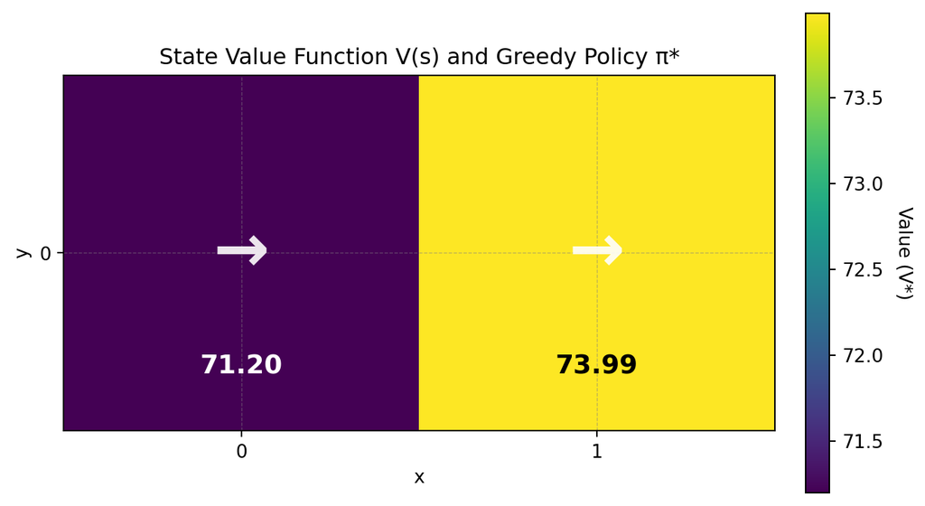

#### 2.3.6 Convergence Plots

The value and action function convergence plots show smooth exponential decay toward stability, confirming numerical convergence of the policy evaluation loop. The policy change plot remains flat at zero, indicating the greedy policy stabilized immediately which is consistent with the simple two state environment where moving right is always optimal.

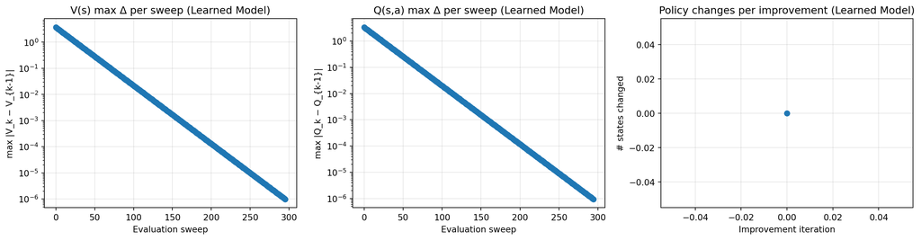

### 2.4 Part 1.4: Simulating the Boat World with Monte Carlo Simulations

```
[MC] Episode 5000
[MC] Episode 10000
[MC] Episode 15000
[MC] Episode 20000
```

```
======================================================================
Optimal State-Value Function V*(s)
======================================================================
i=0 |   69.39 |   72.27
======================================================================

======================================================================
Optimal Action-Value Function Q*(s,a)
======================================================================
State (j=0, i=0) → RIGHT:   69.39, LEFT:   66.39
State (j=1, i=0) → RIGHT:   72.27, LEFT:   70.68
----------------------------------------------------------------------
```

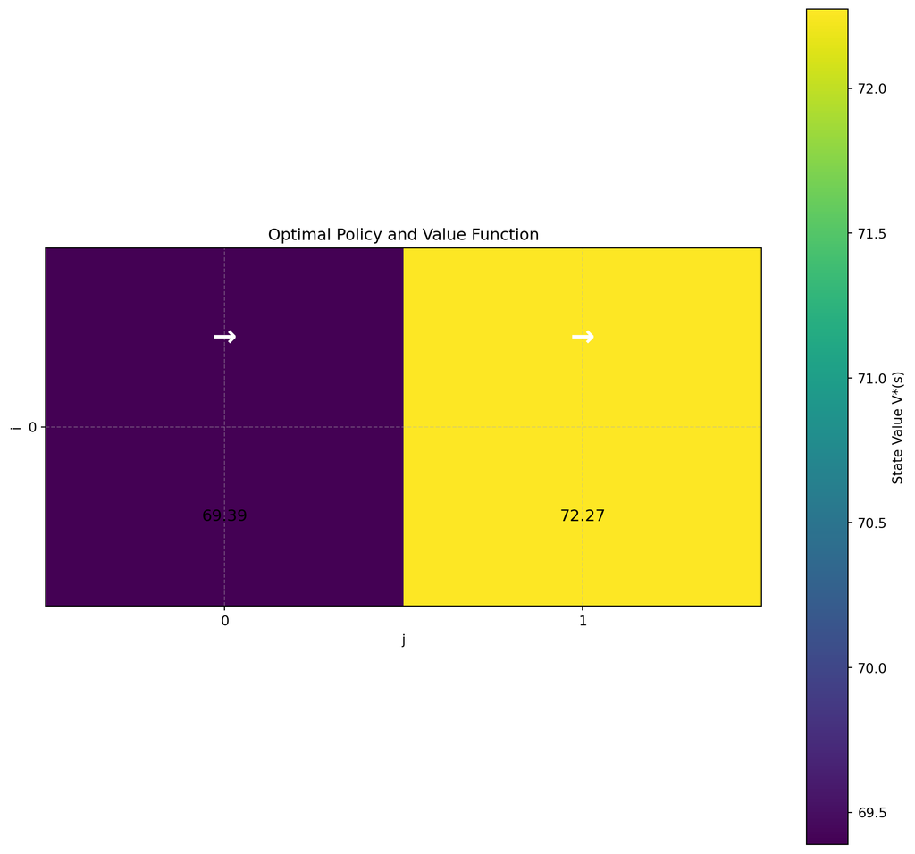

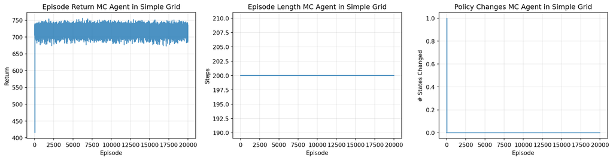

### 2.5 Part 1.5: Simple GridWorld Boat Example - Temporal Difference (Q-Learning)

#### 2.5.1 Simple Gridworld Q Learning Submissions

```
======================================================================
Optimal State-Value Function V*(s)
======================================================================
i=0 |   71.25 |   73.98
======================================================================

======================================================================
Optimal Action-Value Function Q*(s,a)
======================================================================
State (j=0, i=0) → RIGHT:   71.25, LEFT:   68.33
State (j=1, i=0) → RIGHT:   73.98, LEFT:   72.23
----------------------------------------------------------------------
```

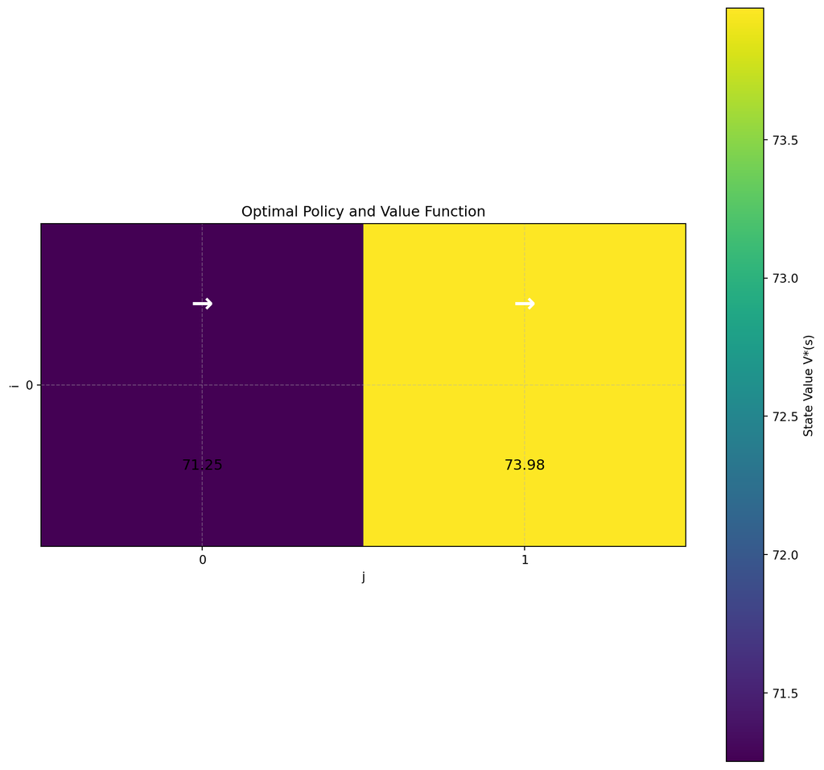

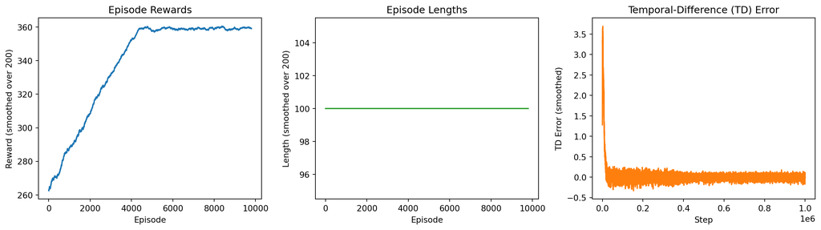

## 3 Part 2: Robot in an Expanded GridWorld

### 3.1 Part 2.1: Run Checks and Demo Quick Visualization

```
Action=3 | Old=(np.int32(0), np.int32(0)) → New=(np.int32(0), np.int32(1)) | Reward=-1
Action=0 | Old=(np.int32(0), np.int32(0)) → New=(np.int32(1), np.int32(0)) | Reward=-1
Action=0 | Old=(np.int32(0), np.int32(0)) → New=(np.int32(1), np.int32(0)) | Reward=-1
Environment passes all checks!
```

```
Step 00 | Action=0 | Obs={'agent': array([1, 0], dtype=int32)} | Reward=-1
Step 01 | Action=3 | Obs={'agent': array([1, 0], dtype=int32)} | Reward=-1
Step 02 | Action=2 | Obs={'agent': array([1, 0], dtype=int32)} | Reward=-1
Step 03 | Action=2 | Obs={'agent': array([1, 1], dtype=int32)} | Reward=-1
Step 04 | Action=2 | Obs={'agent': array([1, 0], dtype=int32)} | Reward=-1
Step 05 | Action=3 | Obs={'agent': array([1, 1], dtype=int32)} | Reward=-1
Step 06 | Action=2 | Obs={'agent': array([0, 1], dtype=int32)} | Reward=-1
Step 07 | Action=3 | Obs={'agent': array([0, 0], dtype=int32)} | Reward=-1
Step 08 | Action=2 | Obs={'agent': array([0, 0], dtype=int32)} | Reward=-1
Step 09 | Action=1 | Obs={'agent': array([0, 0], dtype=int32)} | Reward=-1
Step 10 | Action=3 | Obs={'agent': array([1, 0], dtype=int32)} | Reward=-1
Step 11 | Action=1 | Obs={'agent': array([1, 0], dtype=int32)} | Reward=-1
Step 12 | Action=2 | Obs={'agent': array([0, 0], dtype=int32)} | Reward=-1
Step 13 | Action=1 | Obs={'agent': array([0, 1], dtype=int32)} | Reward=-1
Step 14 | Action=3 | Obs={'agent': array([0, 2], dtype=int32)} | Reward=-1
```

### 3.2 Part 2.2: Dynamic Programming in an Expanded Gridworld

```
[estimate_model] Episode 10000/20000
  Total transitions: 374,989
  Mean count (nonzero cells): 1016.23 | Max count: 15417
  Coverage: 369/5184 (≈ 7.1%)
  P̂(s'|s,a) (rounded):
[[[0.13 0.06 0.   ... 0.   0.   0.  ]
  [0.87 0.06 0.   ... 0.   0.   0.  ]
  [0.87 0.07 0.   ... 0.   0.   0.  ]
  [0.13 0.81 0.   ... 0.   0.   0.  ]]

 [[0.06 0.06 0.06 ... 0.   0.   0.  ]
  [0.06 0.81 0.06 ... 0.   0.   0.  ]
  [0.81 0.07 0.06 ... 0.   0.   0.  ]
  [0.06 0.06 0.81 ... 0.   0.   0.  ]]

 [[0.   0.07 0.06 ... 0.   0.   0.  ]
  [0.   0.06 0.82 ... 0.   0.   0.  ]
  [0.   0.81 0.06 ... 0.   0.   0.  ]
  [0.   0.06 0.06 ... 0.   0.   0.  ]]

 ...

 [[0.   0.   0.   ... 0.86 0.08 0.  ]
  [0.   0.   0.   ... 0.89 0.07 0.  ]
  [0.   0.   0.   ... 0.1  0.11 0.  ]
  [0.   0.   0.   ... 0.12 0.82 0.  ]]

 [[0.   0.   0.   ... 0.08 0.83 0.02]
  [0.   0.   0.   ... 0.07 0.05 0.07]
  [0.   0.   0.   ... 0.82 0.05 0.06]
  [0.   0.   0.   ... 0.08 0.08 0.79]]

 [[0.   0.   0.   ... 0.   0.   0.  ]
  [0.   0.   0.   ... 0.   0.   0.  ]
  [0.   0.   0.   ... 0.   0.   0.  ]
  [0.   0.   0.   ... 0.   0.   0.  ]]]
  Greedy π* preview: [0 2 0 0 2 0 0 0 0 0 0 0 0 0 0 0 0 0 0 2 0 0 0 1 2 0 1 0 3 0 3 0 0 0 3 0]
  V(s) preview (few sweeps):
[[36.66 40.09 43.93 39.75 30.83  0.  ]
 [39.83 43.96 48.69 43.91 38.86 28.72]
```

[output cut: 38 more lines]

```
  [0.   0.   0.   ... 0.   0.   0.  ]
  [0.   0.   0.   ... 0.   0.   0.  ]
  [0.   0.   0.   ... 0.   0.   0.  ]]]
  Greedy π* preview: [0 0 0 1 2 0 0 0 0 0 0 0 0 0 0 0 0 0 0 2 0 0 0 2 2 0 1 0 0 0 0 0 0 0 3 0]
  V(s) preview (few sweeps):
[[36.42 39.84 43.68 39.46 30.7   0.  ]
 [39.58 43.68 48.41 43.58 38.5  28.83]
 [ 0.    0.   53.86  0.    0.    0.  ]
 [42.75 46.55 59.08  0.   84.44 90.58]
 [45.89  0.   65.68  0.   90.79 97.84]
 [57.27 62.78 80.46 89.54 97.    0.  ]]
[estimate_model] Finished training. Building model...
[estimate_model] Model building complete. Returning learned model.
✅ Learned model built from simulation
✅ Policy iteration completed on learned model
```

#### 3.2.1 Expanded Gridworld Dynamic Programming Submissions

```
================================================================================
APPROXIMATED TRANSITION MODEL P̂(s'|s,a) AND R̂(s,a,s')
Shape P̂: (36, 4, 36), Shape R̂: (36, 4, 36)
Only nonzero-count transitions (N > 0) are shown.
================================================================================

State index s=0, coord (j=0, i=0), Action a=0 (RIGHT)
--------------------------------------------------------------------------------
s'_idx |    (j,i) | P̂(s'|s,a) |  R̂(s,a,s') |     N
--------------------------------------------------------------------------------
     0 | (0,0) |      0.125 |      -1.000 |  4422
     1 | (0,1) |      0.061 |      -1.000 |  2157
     6 | (1,0) |      0.814 |      -1.000 | 28824

State index s=0, coord (j=0, i=0), Action a=1 (LEFT)
--------------------------------------------------------------------------------
s'_idx |    (j,i) | P̂(s'|s,a) |  R̂(s,a,s') |     N
--------------------------------------------------------------------------------
     0 | (0,0) |      0.876 |      -1.000 | 30792
     1 | (0,1) |      0.063 |      -1.000 |  2220
     6 | (1,0) |      0.061 |      -1.000 |  2156

State index s=0, coord (j=0, i=0), Action a=2 (UP)
--------------------------------------------------------------------------------
s'_idx |    (j,i) | P̂(s'|s,a) |  R̂(s,a,s') |     N
--------------------------------------------------------------------------------
     0 | (0,0) |      0.871 |      -1.000 | 30687
     1 | (0,1) |      0.065 |      -1.000 |  2286
     6 | (1,0) |      0.065 |      -1.000 |  2279

State index s=0, coord (j=0, i=0), Action a=3 (DOWN)
--------------------------------------------------------------------------------
s'_idx |    (j,i) | P̂(s'|s,a) |  R̂(s,a,s') |     N
--------------------------------------------------------------------------------
     0 | (0,0) |      0.126 |      -1.000 |  4431
     1 | (0,1) |      0.812 |      -1.000 | 28448
     6 | (1,0) |      0.062 |      -1.000 |  2171

State index s=1, coord (j=0, i=1), Action a=0 (RIGHT)
--------------------------------------------------------------------------------
```

[output cut: 96 more lines]

```
----------------------------------------------------------------------
State (j=0, i=4) → RIGHT:   29.74, LEFT:   24.00, UP:   30.70, DOWN:  -35.18
State (j=1, i=4) → RIGHT:   34.81, LEFT:   29.30, UP:   38.50, DOWN:   28.03
State (j=2, i=4) → WALL
State (j=3, i=4) → RIGHT:   84.44, LEFT:   79.89, UP:   80.52, DOWN:   84.17
State (j=4, i=4) → RIGHT:   90.21, LEFT:   81.09, UP:   85.25, DOWN:   90.79
State (j=5, i=4) → RIGHT:   90.68, LEFT:   86.82, UP:   85.46, DOWN:   97.00
----------------------------------------------------------------------
State (j=0, i=5) → TERMINAL, Reward = -50
State (j=1, i=5) → RIGHT:   22.12, LEFT:  -34.86, UP:   28.83, DOWN:   21.48
State (j=2, i=5) → WALL
State (j=3, i=5) → RIGHT:   90.58, LEFT:   84.91, UP:   80.47, DOWN:   85.33
State (j=4, i=5) → RIGHT:   97.84, LEFT:   87.86, UP:   86.81, DOWN:   91.32
State (j=5, i=5) → TERMINAL, Reward = 100
----------------------------------------------------------------------
```

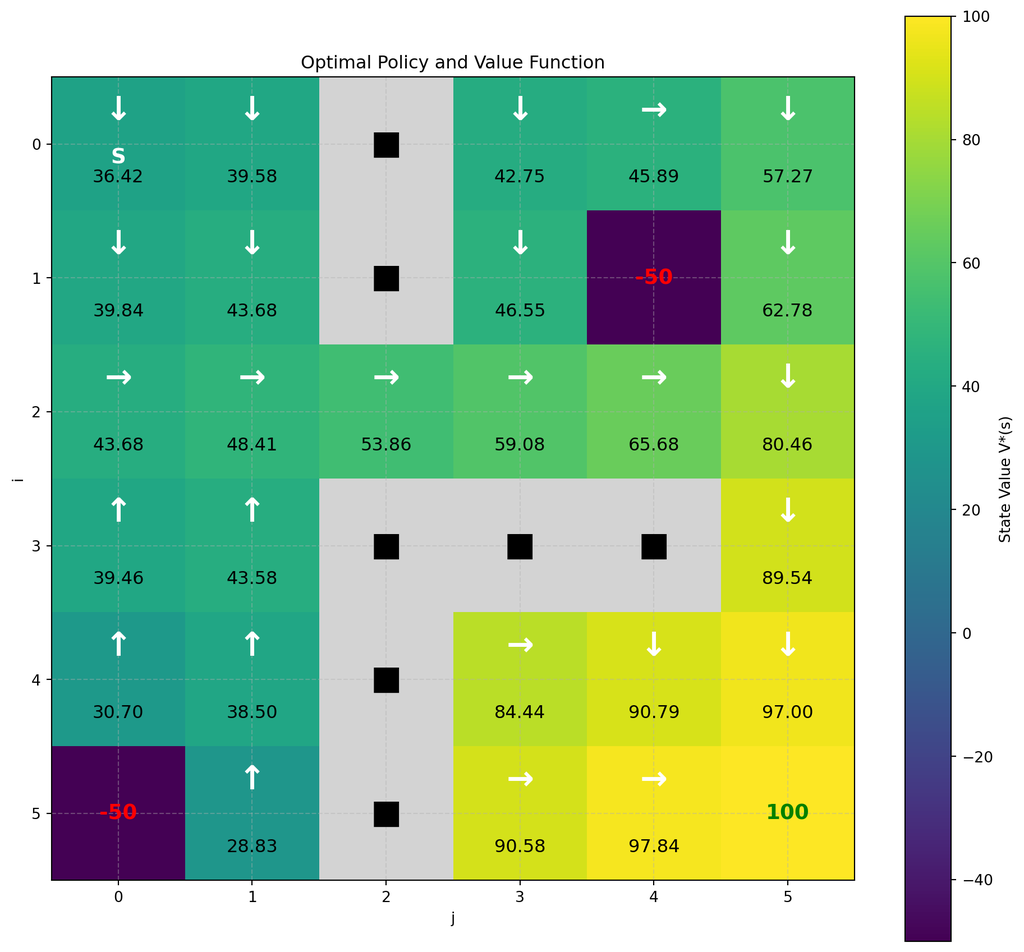

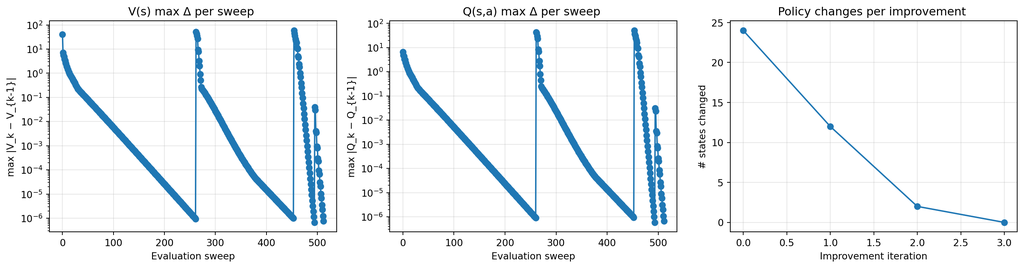

### 3.3 2.3 Monte Carlo in an Expanded Gridworld

```
[MC] Episode   2000 | Return=    87.0 | Length=  14 | Policy changes=0
[MC] Episode   4000 | Return=   -60.0 | Length=  11 | Policy changes=0
[MC] Episode   6000 | Return=    85.0 | Length=  16 | Policy changes=0
[MC] Episode   8000 | Return=    86.0 | Length=  15 | Policy changes=0
[MC] Episode  10000 | Return=    86.0 | Length=  15 | Policy changes=0
[MC] Episode  12000 | Return=    83.0 | Length=  18 | Policy changes=0
[MC] Episode  14000 | Return=    83.0 | Length=  18 | Policy changes=0
[MC] Episode  16000 | Return=    83.0 | Length=  18 | Policy changes=0
[MC] Episode  18000 | Return=    88.0 | Length=  13 | Policy changes=0
[MC] Episode  20000 | Return=    90.0 | Length=  11 | Policy changes=0
[MC] Episode  22000 | Return=    88.0 | Length=  13 | Policy changes=0
[MC] Episode  24000 | Return=    89.0 | Length=  12 | Policy changes=0
[MC] Episode  26000 | Return=    84.0 | Length=  17 | Policy changes=0
[MC] Episode  28000 | Return=    83.0 | Length=  18 | Policy changes=0
[MC] Episode  30000 | Return=    91.0 | Length=  10 | Policy changes=0
```

#### 3.3.1 Expanded Gridworld Monte Carlo Submissions

```
======================================================================
Optimal State-Value Function V*(s)
======================================================================
i=0 |   29.09 |   32.31 |    WALL  |   35.69 |   27.83 |   48.38
i=1 |   32.56 |   36.45 |    WALL  |   39.40 |     -50 |   60.18
i=2 |   35.77 |   41.29 |   47.02 |   52.50 |   62.24 |   78.50
i=3 |   27.95 |   35.92 |    WALL  |    WALL  |    WALL  |   88.68
i=4 |   25.85 |   31.43 |    WALL  |   82.56 |   89.12 |   97.36
i=5 |     -50 |   32.98 |    WALL  |   88.73 |   97.43 |     100
======================================================================

======================================================================
Optimal Action-Value Function Q*(s,a)
======================================================================
State (j=0, i=0) → RIGHT:   29.09, LEFT:   25.44, UP:   25.89, DOWN:   27.51
State (j=1, i=0) → RIGHT:   27.81, LEFT:   25.70, UP:   26.96, DOWN:   32.31
State (j=2, i=0) → WALL
State (j=3, i=0) → RIGHT:   13.60, LEFT:   18.33, UP:   10.48, DOWN:   35.69
State (j=4, i=0) → RIGHT:    1.65, LEFT:   27.83, UP:  -44.47, DOWN:  -22.60
State (j=5, i=0) → RIGHT:   18.09, LEFT:   27.09, UP:   36.74, DOWN:   48.38
----------------------------------------------------------------------
State (j=0, i=1) → RIGHT:   32.56, LEFT:   21.07, UP:   20.35, DOWN:   22.38
State (j=1, i=1) → RIGHT:   31.24, LEFT:   29.77, UP:   28.24, DOWN:   36.45
State (j=2, i=1) → WALL
State (j=3, i=1) → RIGHT:  -32.10, LEFT:   28.98, UP:   24.18, DOWN:   39.40
State (j=4, i=1) → TERMINAL, Reward = -50
State (j=5, i=1) → RIGHT:   35.55, LEFT:  -33.02, UP:   34.87, DOWN:   60.18
----------------------------------------------------------------------
State (j=0, i=2) → RIGHT:   35.77, LEFT:   18.97, UP:   16.34, DOWN:   20.67
State (j=1, i=2) → RIGHT:   41.29, LEFT:   32.22, UP:   31.95, DOWN:   32.12
State (j=2, i=2) → RIGHT:   47.02, LEFT:   36.40, UP:   41.42, DOWN:   40.30
State (j=3, i=2) → RIGHT:   52.50, LEFT:   43.50, UP:   37.32, DOWN:   47.81
State (j=4, i=2) → RIGHT:   62.24, LEFT:   44.49, UP:  -31.60, DOWN:   48.30
State (j=5, i=2) → RIGHT:   70.27, LEFT:   58.42, UP:   56.74, DOWN:   78.50
----------------------------------------------------------------------
State (j=0, i=3) → RIGHT:   13.40, LEFT:    7.27, UP:   27.95, DOWN:    6.59
State (j=1, i=3) → RIGHT:   31.93, LEFT:   12.06, UP:   35.92, DOWN:   28.51
State (j=2, i=3) → WALL
State (j=3, i=3) → WALL
State (j=4, i=3) → WALL
State (j=5, i=3) → RIGHT:   82.27, LEFT:   82.32, UP:   73.92, DOWN:   88.68
----------------------------------------------------------------------
State (j=0, i=4) → RIGHT:   25.85, LEFT:  -14.53, UP:   -7.52, DOWN:  -43.68
State (j=1, i=4) → RIGHT:    2.26, LEFT:   14.13, UP:   31.43, DOWN:   19.12
State (j=2, i=4) → WALL
State (j=3, i=4) → RIGHT:   82.56, LEFT:   77.64, UP:   63.20, DOWN:   80.94
State (j=4, i=4) → RIGHT:   89.12, LEFT:   79.52, UP:   83.77, DOWN:   88.51
State (j=5, i=4) → RIGHT:   89.76, LEFT:   84.12, UP:   84.39, DOWN:   97.36
----------------------------------------------------------------------
State (j=0, i=5) → TERMINAL, Reward = -50
State (j=1, i=5) → RIGHT:  -13.85, LEFT:  -50.00, UP:   32.98, DOWN:  -26.21
State (j=2, i=5) → WALL
State (j=3, i=5) → RIGHT:   88.73, LEFT:   77.28, UP:   82.88, DOWN:   51.85
State (j=4, i=5) → RIGHT:   97.43, LEFT:   83.55, UP:   81.79, DOWN:   93.23
State (j=5, i=5) → TERMINAL, Reward = 100
----------------------------------------------------------------------
```

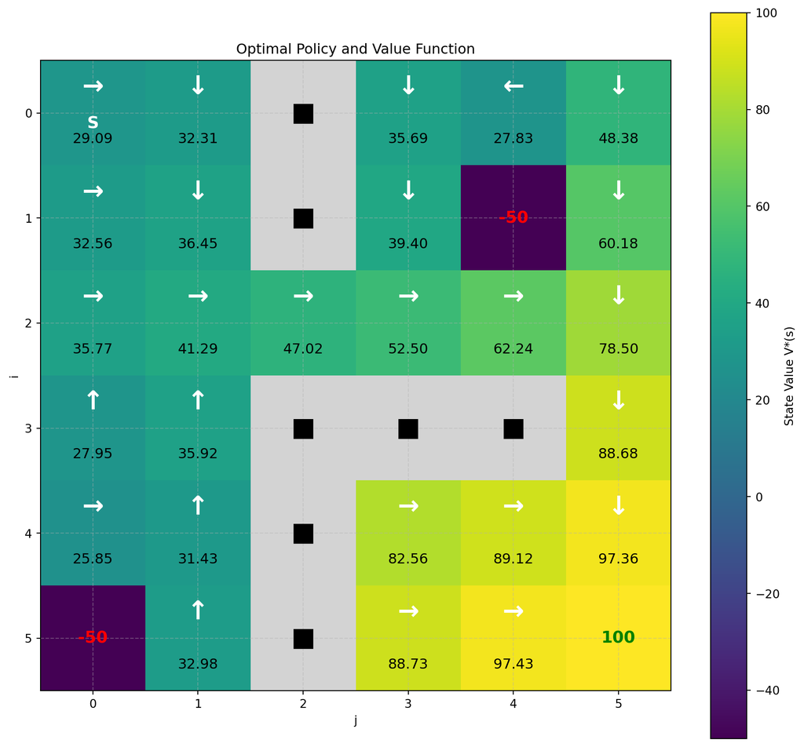

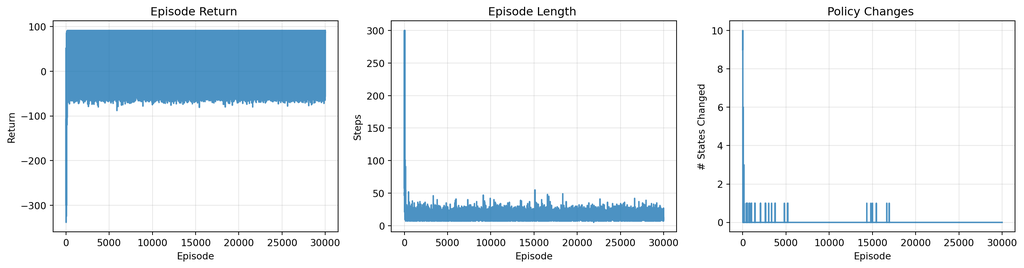

### 3.4 2.4 Q Learning in an Expanded Gridworld

```
[Q-Learning] Episode  10000 | Return =    90.00 | Steps =  11 | Policy changes = 0
[Q-Learning] Episode  20000 | Return =    84.00 | Steps =  17 | Policy changes = 0
[Q-Learning] Episode  30000 | Return =    86.00 | Steps =  15 | Policy changes = 0
[Q-Learning] Episode  40000 | Return =    88.00 | Steps =  13 | Policy changes = 0
[Q-Learning] Episode  50000 | Return =    87.00 | Steps =  14 | Policy changes = 0
```

#### 3.4.1 Expanded Gridworld Q Learning Submissions

```
======================================================================
Optimal State-Value Function V*(s)
======================================================================
i=0 |   32.51 |   34.39 |    WALL  |   37.65 |   31.23 |   51.90
i=1 |   35.10 |   37.31 |    WALL  |   35.84 |     -50 |   64.03
i=2 |   38.43 |   41.56 |   49.15 |   59.05 |   71.09 |   79.76
i=3 |   33.01 |   38.25 |    WALL  |    WALL  |    WALL  |   90.71
i=4 |   25.13 |   34.06 |    WALL  |   83.66 |   90.92 |   98.62
i=5 |     -50 |   25.20 |    WALL  |   91.06 |   97.01 |     100
======================================================================

======================================================================
Optimal Action-Value Function Q*(s,a)
======================================================================
State (j=0, i=0) → RIGHT:   32.51, LEFT:   28.84, UP:   28.96, DOWN:   30.73
State (j=1, i=0) → RIGHT:   32.14, LEFT:   30.04, UP:   30.69, DOWN:   34.39
State (j=2, i=0) → WALL
State (j=3, i=0) → RIGHT:   37.65, LEFT:   27.77, UP:   26.19, DOWN:   29.02
State (j=4, i=0) → RIGHT:   31.23, LEFT:   20.68, UP:   11.29, DOWN:  -23.43
State (j=5, i=0) → RIGHT:   38.23, LEFT:   27.10, UP:   41.47, DOWN:   51.90
----------------------------------------------------------------------
State (j=0, i=1) → RIGHT:   35.10, LEFT:   30.68, UP:   30.31, DOWN:   30.68
State (j=1, i=1) → RIGHT:   32.49, LEFT:   31.85, UP:   32.27, DOWN:   37.31
State (j=2, i=1) → WALL
State (j=3, i=1) → RIGHT:  -42.74, LEFT:   20.40, UP:   17.41, DOWN:   35.84
State (j=4, i=1) → TERMINAL, Reward = -50
State (j=5, i=1) → RIGHT:   37.33, LEFT:  -34.92, UP:   35.57, DOWN:   64.03
----------------------------------------------------------------------
State (j=0, i=2) → RIGHT:   38.43, LEFT:   31.73, UP:   31.57, DOWN:   31.82
State (j=1, i=2) → RIGHT:   41.56, LEFT:   33.01, UP:   35.05, DOWN:   33.79
State (j=2, i=2) → RIGHT:   49.15, LEFT:   36.75, UP:   37.43, DOWN:   40.18
State (j=3, i=2) → RIGHT:   59.05, LEFT:   38.35, UP:   37.96, DOWN:   40.01
State (j=4, i=2) → RIGHT:   71.09, LEFT:   34.32, UP:  -32.16, DOWN:   25.43
State (j=5, i=2) → RIGHT:   71.59, LEFT:   60.45, UP:   59.82, DOWN:   79.76
----------------------------------------------------------------------
State (j=0, i=3) → RIGHT:   33.01, LEFT:   29.51, UP:   29.62, DOWN:   26.78
State (j=1, i=3) → RIGHT:   32.83, LEFT:   32.75, UP:   38.25, DOWN:   32.07
State (j=2, i=3) → WALL
State (j=3, i=3) → WALL
State (j=4, i=3) → WALL
State (j=5, i=3) → RIGHT:   84.22, LEFT:   82.79, UP:   77.97, DOWN:   90.71
----------------------------------------------------------------------
State (j=0, i=4) → RIGHT:   25.13, LEFT:    7.75, UP:   22.79, DOWN:  -35.52
State (j=1, i=4) → RIGHT:   28.13, LEFT:   25.57, UP:   34.06, DOWN:   22.35
State (j=2, i=4) → WALL
State (j=3, i=4) → RIGHT:   47.41, LEFT:   64.13, UP:   54.97, DOWN:   83.66
State (j=4, i=4) → RIGHT:   87.08, LEFT:   79.76, UP:   85.71, DOWN:   90.92
State (j=5, i=4) → RIGHT:   91.24, LEFT:   86.19, UP:   85.06, DOWN:   98.62
----------------------------------------------------------------------
State (j=0, i=5) → TERMINAL, Reward = -50
State (j=1, i=5) → RIGHT:   -2.89, LEFT:  -16.20, UP:   25.20, DOWN:    1.05
State (j=2, i=5) → WALL
State (j=3, i=5) → RIGHT:   91.06, LEFT:   74.49, UP:   68.09, DOWN:   62.01
State (j=4, i=5) → RIGHT:   97.01, LEFT:   84.52, UP:   86.23, DOWN:   91.97
State (j=5, i=5) → TERMINAL, Reward = 100
----------------------------------------------------------------------
```

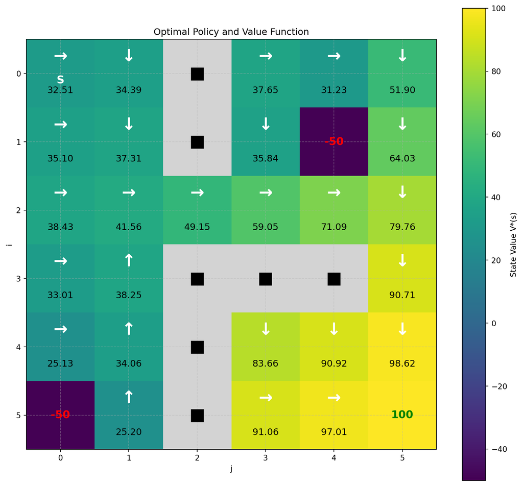

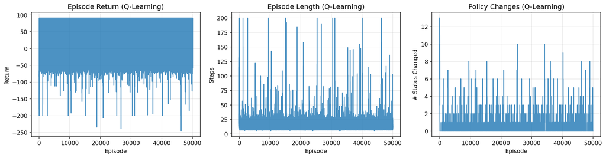

## 4 Part 3: Geosearch in GridWorld

### 4.1 Part 2.1: Run Checks and Demo Quick Visualization

```
Environment passes all checks!
```

```
Step 00 | Action=3 | Obs={'agent': array([0, 1], dtype=int32)} | Reward=1.4993989183274656e-53
Step 01 | Action=2 | Obs={'agent': array([0, 0], dtype=int32)} | Reward=4.139499408260667e-59
Step 02 | Action=2 | Obs={'agent': array([0, 0], dtype=int32)} | Reward=4.139499408260667e-59
Step 03 | Action=1 | Obs={'agent': array([0, 0], dtype=int32)} | Reward=4.139499408260667e-59
Step 04 | Action=1 | Obs={'agent': array([0, 0], dtype=int32)} | Reward=4.139499408260667e-59
Step 05 | Action=0 | Obs={'agent': array([1, 0], dtype=int32)} | Reward=1.4993989183274656e-53
Step 06 | Action=0 | Obs={'agent': array([2, 0], dtype=int32)} | Reward=1.8691283048480957e-48
Step 07 | Action=0 | Obs={'agent': array([3, 0], dtype=int32)} | Reward=8.018877662360986e-44
Step 08 | Action=0 | Obs={'agent': array([4, 0], dtype=int32)} | Reward=1.1839697708584619e-39
Step 09 | Action=3 | Obs={'agent': array([4, 1], dtype=int32)} | Reward=1.4759190391204162e-34
Step 10 | Action=2 | Obs={'agent': array([4, 0], dtype=int32)} | Reward=1.1839697708584619e-39
Step 11 | Action=3 | Obs={'agent': array([4, 1], dtype=int32)} | Reward=1.4759190391204162e-34
Step 12 | Action=2 | Obs={'agent': array([4, 0], dtype=int32)} | Reward=1.1839697708584619e-39
Step 13 | Action=2 | Obs={'agent': array([4, 0], dtype=int32)} | Reward=1.1839697708584619e-39
Step 14 | Action=3 | Obs={'agent': array([4, 1], dtype=int32)} | Reward=1.4759190391204162e-34
```

### 4.2 Part 3.2: Dynamic Programming in an Geosearch Gridworld

#### 4.2.1 Geosearch Gridworld Dynamic Programming Submissions

```
======================================================================
Optimal State-Value Function V*(s)
======================================================================
i=0 |    2.69 |    2.83 |    2.98 |    3.14 |    3.30 |    3.48 |    3.66 |    3.85 |    4.05 |    4.27 |    4.45 |    4.42 |    4.40 |    4.56 |    4.79 |    5.05 |    5.31 |    5.59 |    5.89 |    6.18 |    6.31 |    6.07 |    5.77 |    5.48 |    5.21
i=1 |    2.83 |    2.98 |    3.14 |    3.30 |    3.48 |    3.66 |    3.85 |    4.05 |    4.27 |    4.49 |    4.68 |    4.66 |    4.63 |    4.80 |    5.05 |    5.31 |    5.59 |    5.89 |    6.20 |    6.51 |    6.65 |    6.39 |    6.07 |    5.77 |    5.48
i=2 |    2.98 |    3.14 |    3.30 |    3.48 |    3.66 |    3.85 |    4.05 |    4.27 |    4.49 |    4.73 |    4.93 |    4.90 |    4.87 |    5.05 |    5.31 |    5.59 |    5.89 |    6.20 |    6.52 |    6.85 |    7.00 |    6.73 |    6.39 |    6.07 |    5.77
i=3 |    3.14 |    3.30 |    3.48 |    3.66 |    3.85 |    4.05 |    4.27 |    4.49 |    4.73 |    4.98 |    5.19 |    5.16 |    5.13 |    5.32 |    5.59 |    5.89 |    6.20 |    6.52 |    6.86 |    7.21 |    7.36 |    7.08 |    6.73 |    6.39 |    6.07
i=4 |    3.30 |    3.48 |    3.66 |    3.85 |    4.05 |    4.27 |    4.49 |    4.73 |    4.98 |    5.24 |    5.46 |    5.43 |    5.40 |    5.60 |    5.89 |    6.20 |    6.52 |    6.87 |    7.23 |    7.59 |    7.75 |    7.45 |    7.08 |    6.73 |    6.39
i=5 |    3.48 |    3.66 |    3.85 |    4.05 |    4.27 |    4.49 |    4.73 |    4.98 |    5.24 |    5.51 |    5.75 |    5.72 |    5.68 |    5.89 |    6.20 |    6.52 |    6.87 |    7.23 |    7.61 |    7.99 |    8.16 |    7.84 |    7.45 |    7.08 |    6.73
i=6 |    3.66 |    3.85 |    4.05 |    4.27 |    4.49 |    4.73 |    4.98 |    5.24 |    5.52 |    5.81 |    6.05 |    6.02 |    5.98 |    6.20 |    6.52 |    6.87 |    7.23 |    7.61 |    8.01 |    8.41 |    8.59 |    8.26 |    7.85 |    7.45 |    7.08
i=7 |    3.85 |    4.05 |    4.27 |    4.49 |    4.73 |    4.98 |    5.24 |    5.52 |    5.81 |    6.11 |    6.37 |    6.33 |    6.30 |    6.53 |    6.87 |    7.23 |    7.61 |    8.01 |    8.43 |    8.85 |    9.04 |    8.69 |    8.26 |    7.85 |    7.45
i=8 |    4.05 |    4.27 |    4.49 |    4.73 |    4.98 |    5.24 |    5.52 |    5.81 |    6.11 |    6.42 |    6.66 |    6.62 |    6.61 |    6.87 |    7.23 |    7.61 |    8.01 |    8.43 |    8.87 |    9.32 |    9.52 |    9.15 |    8.69 |    8.26 |    7.85
i=9 |    4.27 |    4.49 |    4.73 |    4.98 |    5.24 |    5.51 |    5.81 |    6.11 |    6.42 |    6.66 |    6.81 |    6.81 |    6.92 |    7.23 |    7.61 |    8.01 |    8.43 |    8.87 |    9.34 |    9.81 |   10.02 |    9.63 |    9.15 |    8.69 |    8.26
i=10 |    4.45 |    4.68 |    4.93 |    5.19 |    5.46 |    5.75 |    6.05 |    6.37 |    6.66 |    6.81 |    6.81 |    6.97 |    7.24 |    7.61 |    8.01 |    8.43 |    8.87 |    9.34 |    9.83 |   10.32 |   10.54 |   10.14 |    9.63 |    9.15 |    8.69
i=11 |    4.42 |    4.66 |    4.90 |    5.16 |    5.43 |    5.72 |    6.02 |    6.33 |    6.62 |    6.81 |    6.97 |    7.24 |    7.61 |    8.01 |    8.43 |    8.87 |    9.34 |    9.83 |   10.35 |   10.87 |   11.10 |   10.67 |   10.14 |    9.63 |    9.15
i=12 |    4.40 |    4.63 |    4.87 |    5.13 |    5.40 |    5.68 |    5.98 |    6.30 |    6.61 |    6.92 |    7.24 |    7.61 |    8.01 |    8.43 |    8.87 |    9.34 |    9.83 |   10.35 |   10.89 |   11.44 |   11.68 |   11.23 |   10.67 |   10.14 |    9.63
i=13 |    4.56 |    4.80 |    5.05 |    5.32 |    5.60 |    5.89 |    6.20 |    6.53 |    6.87 |    7.23 |    7.61 |    8.01 |    8.43 |    8.87 |    9.34 |    9.83 |   10.35 |   10.89 |   11.47 |   12.04 |   12.30 |   11.82 |   11.24 |   10.67 |   10.14
```

[output cut: 666 more lines]

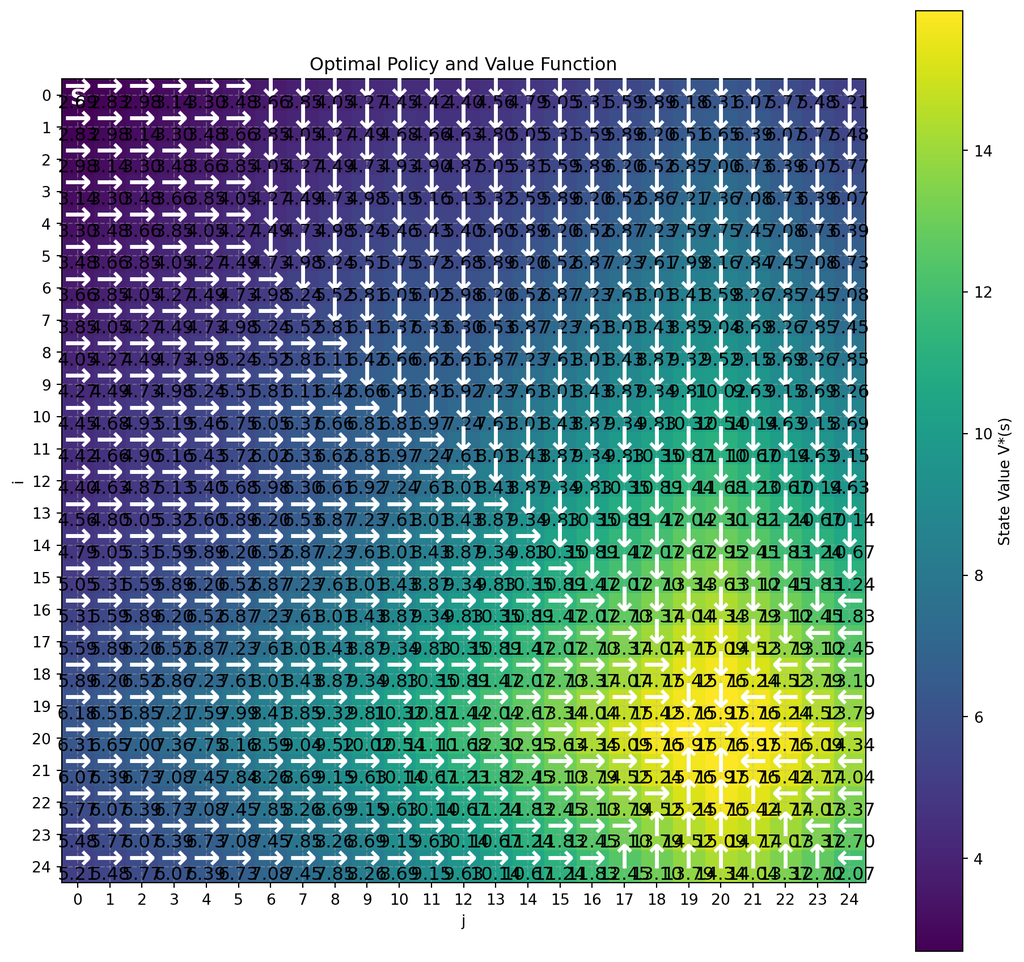

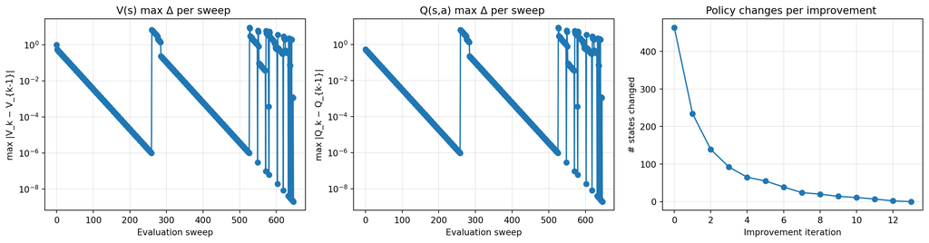

### 4.3 3.3 Monte Carlo in an Geosearch Gridworld

```
[GeoSearch-MC] Episode   1000 | Return=  191.59 | Length= 300 | Policy changes=0
[GeoSearch-MC] Episode   2000 | Return=  198.46 | Length= 300 | Policy changes=0
[GeoSearch-MC] Episode   3000 | Return=  194.63 | Length= 300 | Policy changes=0
[GeoSearch-MC] Episode   4000 | Return=  196.18 | Length= 300 | Policy changes=0
[GeoSearch-MC] Episode   5000 | Return=  201.54 | Length= 300 | Policy changes=0
[GeoSearch-MC] Episode   6000 | Return=  195.83 | Length= 300 | Policy changes=0
[GeoSearch-MC] Episode   7000 | Return=  199.60 | Length= 300 | Policy changes=0
[GeoSearch-MC] Episode   8000 | Return=  203.40 | Length= 300 | Policy changes=0
[GeoSearch-MC] Episode   9000 | Return=  200.43 | Length= 300 | Policy changes=0
[GeoSearch-MC] Episode  10000 | Return=  202.12 | Length= 300 | Policy changes=0
```

#### 4.3.1 Geosearch Gridworld Monte Carlo Submissions

```
======================================================================
Optimal State-Value Function V*(s)
======================================================================
i=0 |    1.98 |    1.87 |    1.75 |    0.11 |    0.45 |    0.25 |    0.15 |    1.85 |    0.02 |    0.22 |    0.23 |    0.24 |    0.51 |    0.30 |    0.31 |    0.66 |    0.37 |    0.39 |    0.41 |    0.43 |    0.45 |    0.10 |    0.11 |    0.13 |    0.12
i=1 |    2.11 |    1.84 |    1.42 |    0.73 |    0.56 |    0.30 |    0.32 |    0.75 |    0.38 |    0.42 |    0.03 |    0.03 |    0.03 |    0.21 |    0.00 |    0.00 |    0.00 |    0.00 |    0.00 |    0.00 |    0.00 |    0.00 |    0.00 |    0.00 |    0.80
i=2 |    2.23 |    2.09 |    1.35 |    1.08 |    2.65 |    1.99 |    0.61 |    1.69 |    1.87 |    3.32 |    2.39 |    0.11 |    0.00 |    0.01 |    0.02 |    0.00 |    0.00 |    0.00 |    0.00 |    0.00 |    0.00 |    0.00 |    2.59 |    1.23 |    0.32
i=3 |    2.36 |    2.50 |    1.99 |    2.11 |    2.12 |    2.33 |    2.00 |    1.76 |    3.05 |    3.00 |    2.14 |    1.82 |    1.04 |    0.84 |    1.18 |    0.17 |    0.43 |    0.18 |    0.00 |    0.00 |    0.00 |    0.86 |    1.02 |    0.00 |    0.16
i=4 |    2.54 |    2.71 |    2.63 |    1.79 |    1.19 |    2.40 |    2.52 |    2.73 |    3.00 |    2.13 |    0.73 |    2.94 |    1.10 |    0.18 |    0.59 |    1.31 |    0.33 |    0.43 |    0.00 |    0.00 |    1.06 |    1.01 |    0.00 |    0.00 |    0.00
i=5 |    2.70 |    2.86 |    3.01 |    3.22 |    3.33 |    3.85 |    3.48 |    3.50 |    3.28 |    2.03 |    3.30 |    2.94 |    1.36 |    0.62 |    1.30 |    4.50 |    2.08 |    0.31 |    0.00 |    0.01 |    1.22 |    0.15 |    1.31 |    0.00 |    0.00
i=6 |    2.91 |    2.90 |    3.19 |    3.39 |    3.59 |    3.79 |    3.66 |    3.71 |    4.58 |    3.05 |    2.80 |    0.45 |    0.54 |    1.62 |    1.25 |    0.55 |    1.52 |    2.76 |    0.61 |    1.10 |    1.15 |    0.02 |    0.27 |    0.22 |    0.22
i=7 |    2.93 |    3.07 |    3.22 |    3.43 |    3.81 |    4.03 |    4.28 |    4.09 |    4.76 |    5.19 |    3.44 |    2.14 |    2.32 |    2.30 |    2.71 |    2.20 |    3.37 |    2.65 |    3.68 |    1.83 |    3.54 |    2.19 |    0.82 |    0.77 |    0.72
i=8 |    3.14 |    3.25 |    3.45 |    3.69 |    3.84 |    4.37 |    4.63 |    4.96 |    5.23 |    5.55 |    5.21 |    5.69 |    5.89 |    2.88 |    3.64 |    3.03 |    2.08 |    1.93 |    3.32 |    4.14 |    3.70 |    4.93 |    2.96 |    3.15 |    1.74
i=9 |    3.31 |    3.35 |    3.56 |    3.78 |    4.04 |    4.18 |    4.43 |    4.82 |    5.12 |    5.78 |    5.89 |    5.80 |    4.34 |    2.89 |    4.26 |    3.81 |    4.11 |    4.29 |    4.54 |    4.93 |    4.30 |    4.80 |    5.32 |    5.05 |    3.14
i=10 |    3.48 |    3.66 |    3.66 |    3.91 |    4.11 |    4.30 |    4.87 |    5.17 |    5.43 |    5.49 |    5.98 |    6.15 |    5.83 |    3.24 |    5.11 |    7.57 |    4.39 |    4.27 |    4.55 |    5.26 |    5.48 |    4.28 |    3.63 |    3.14 |    3.48
i=11 |    0.00 |    0.00 |    0.00 |    0.00 |    4.34 |    4.57 |    4.82 |    5.08 |    5.29 |    5.64 |    6.10 |    6.36 |    6.68 |    6.31 |    6.33 |    4.75 |    3.71 |    6.57 |    4.95 |    6.18 |    6.33 |    5.80 |    6.69 |    5.26 |    4.52
i=12 |    0.00 |    0.00 |    0.00 |    0.00 |    4.17 |    4.60 |    5.00 |    5.41 |    5.60 |    5.97 |    6.05 |    6.71 |    7.00 |    7.40 |    7.84 |    8.11 |    4.94 |    6.53 |    7.14 |    7.82 |    7.25 |    9.02 |    8.48 |    7.66 |    3.34
i=13 |    0.00 |    0.00 |    0.00 |    0.00 |    0.00 |    0.00 |    5.24 |    5.58 |    5.95 |    6.31 |    6.65 |    7.07 |    7.50 |    7.96 |    8.10 |    8.64 |    8.39 |    6.57 |    6.12 |    5.17 |    6.86 |    7.14 |    8.68 |    6.21 |    1.58
```

[output cut: 666 more lines]

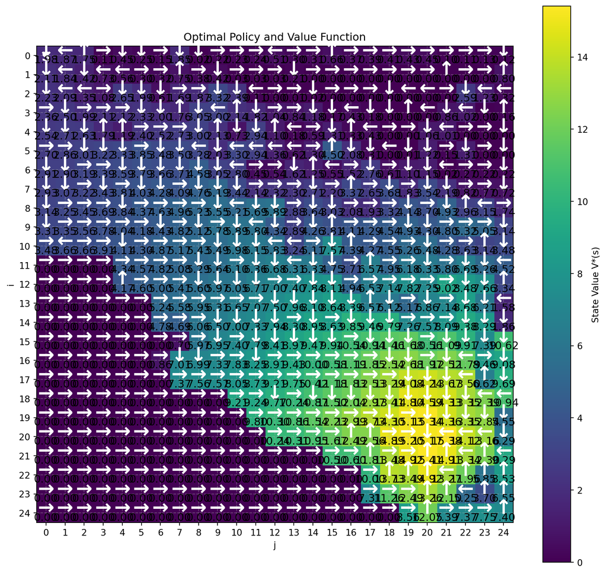

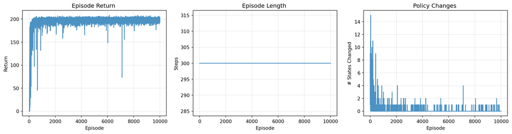

### 4.4 Part 3.4: Q Learning in an Geosearch Gridworld

```
[Q-Learning] Episode   4000 | Return =   249.80 | Steps = 1000 | Policy changes = 0
[Q-Learning] Episode   8000 | Return =   250.57 | Steps = 1000 | Policy changes = 0
[Q-Learning] Episode  12000 | Return =   248.30 | Steps = 1000 | Policy changes = 0
[Q-Learning] Episode  16000 | Return =   250.34 | Steps = 1000 | Policy changes = 0
[Q-Learning] Episode  20000 | Return =   249.16 | Steps = 1000 | Policy changes = 0
```

#### 4.4.1 Geosearch Gridworld Q Learning Submissions

```
======================================================================
Optimal State-Value Function V*(s)
======================================================================
i=0 |    1.96 |    2.06 |    2.17 |    2.28 |    2.40 |    2.53 |    2.66 |    2.80 |    2.95 |    3.11 |    2.88 |    2.87 |    0.00 |    0.00 |    0.00 |    0.00 |    0.00 |    0.00 |    0.00 |    0.00 |    0.00 |    0.00 |    0.00 |    0.00 |    0.00
i=1 |    1.86 |    1.96 |    2.06 |    2.17 |    2.53 |    2.66 |    2.80 |    2.95 |    3.11 |    3.27 |    3.11 |    3.27 |    1.63 |    0.00 |    0.00 |    0.00 |    0.00 |    0.04 |    0.00 |    0.00 |    0.00 |    0.00 |    0.00 |    0.00 |    0.00
i=2 |    1.18 |    1.63 |    1.92 |    1.16 |    2.26 |    2.78 |    2.95 |    3.11 |    3.27 |    3.44 |    3.62 |    3.44 |    2.52 |    2.76 |    2.95 |    2.75 |    1.50 |    0.39 |    0.02 |    0.00 |    0.00 |    0.00 |    0.00 |    0.00 |    0.00
i=3 |    0.00 |    0.00 |    0.18 |    0.02 |    0.54 |    0.35 |    2.08 |    3.15 |    3.44 |    3.62 |    3.81 |    4.01 |    2.81 |    2.96 |    3.11 |    3.28 |    0.30 |    0.00 |    0.00 |    0.00 |    0.00 |    0.00 |    0.00 |    0.00 |    0.00
i=4 |    0.00 |    0.00 |    0.00 |    0.00 |    0.00 |    0.00 |    0.00 |    0.37 |    2.93 |    3.81 |    4.01 |    4.22 |    4.02 |    3.11 |    3.28 |    3.45 |    3.19 |    0.00 |    0.00 |    0.00 |    0.00 |    0.00 |    0.00 |    0.00 |    0.00
i=5 |    0.00 |    0.00 |    0.00 |    0.00 |    0.00 |    0.00 |    0.00 |    0.01 |    0.70 |    3.49 |    4.22 |    4.45 |    4.23 |    4.02 |    3.82 |    3.63 |    1.81 |    0.48 |    0.00 |    0.00 |    0.00 |    0.00 |    0.00 |    0.00 |    0.00
i=6 |    0.00 |    0.00 |    0.00 |    0.00 |    0.00 |    0.00 |    0.00 |    0.00 |    0.15 |    1.44 |    4.45 |    4.68 |    4.46 |    4.23 |    4.02 |    3.81 |    3.32 |    2.56 |    0.09 |    0.00 |    0.00 |    0.00 |    0.00 |    0.00 |    0.00
i=7 |    0.00 |    0.00 |    0.00 |    0.00 |    0.00 |    0.00 |    0.00 |    0.00 |    3.19 |    4.42 |    4.68 |    4.92 |    4.69 |    4.46 |    4.23 |    0.40 |    0.71 |    1.72 |    0.00 |    0.00 |    0.00 |    0.00 |    0.00 |    0.00 |    0.00
i=8 |    0.00 |    0.00 |    0.00 |    0.00 |    0.00 |    0.00 |    0.00 |    3.87 |    4.84 |    5.07 |    5.25 |    5.14 |    4.92 |    4.69 |    4.45 |    0.03 |    0.26 |    0.72 |    0.00 |    0.00 |    0.00 |    0.00 |    0.00 |    0.00 |    0.00
i=9 |    0.00 |    0.00 |    0.00 |    0.00 |    0.00 |    0.00 |    0.71 |    4.69 |    5.08 |    5.25 |    5.32 |    5.25 |    5.14 |    4.92 |    4.68 |    0.01 |    0.06 |    0.00 |    0.00 |    0.00 |    0.00 |    0.00 |    0.00 |    0.00 |    0.00
i=10 |    0.00 |    0.00 |    0.00 |    0.00 |    0.00 |    0.00 |    1.16 |    5.03 |    5.25 |    5.32 |    5.25 |    5.32 |    5.25 |    5.03 |    4.37 |    0.42 |    0.00 |    0.00 |    0.00 |    0.00 |    0.00 |    0.00 |    0.00 |    0.00 |    0.00
i=11 |    0.00 |    0.00 |    0.00 |    0.00 |    0.00 |    0.00 |    0.39 |    4.32 |    5.14 |    5.25 |    5.32 |    5.25 |    5.08 |    4.84 |    4.60 |    2.81 |    0.00 |    0.00 |    0.00 |    0.00 |    0.00 |    0.00 |    0.00 |    0.00 |    0.00
i=12 |    0.00 |    0.00 |    0.00 |    0.00 |    0.00 |    0.00 |    0.00 |    0.00 |    4.52 |    5.03 |    5.25 |    5.08 |    4.37 |    4.60 |    4.25 |    0.00 |    0.00 |    0.00 |    0.00 |    0.00 |    0.00 |    0.00 |    0.00 |    0.00 |    0.00
i=13 |    0.00 |    0.00 |    0.00 |    0.00 |    0.00 |    0.00 |    0.00 |    0.00 |    0.27 |    3.37 |    3.75 |    3.94 |    4.15 |    4.37 |    2.64 |    0.00 |    0.00 |    0.00 |    0.00 |    0.00 |    0.00 |    0.00 |    0.00 |    0.00 |    0.05
```

[output cut: 666 more lines]

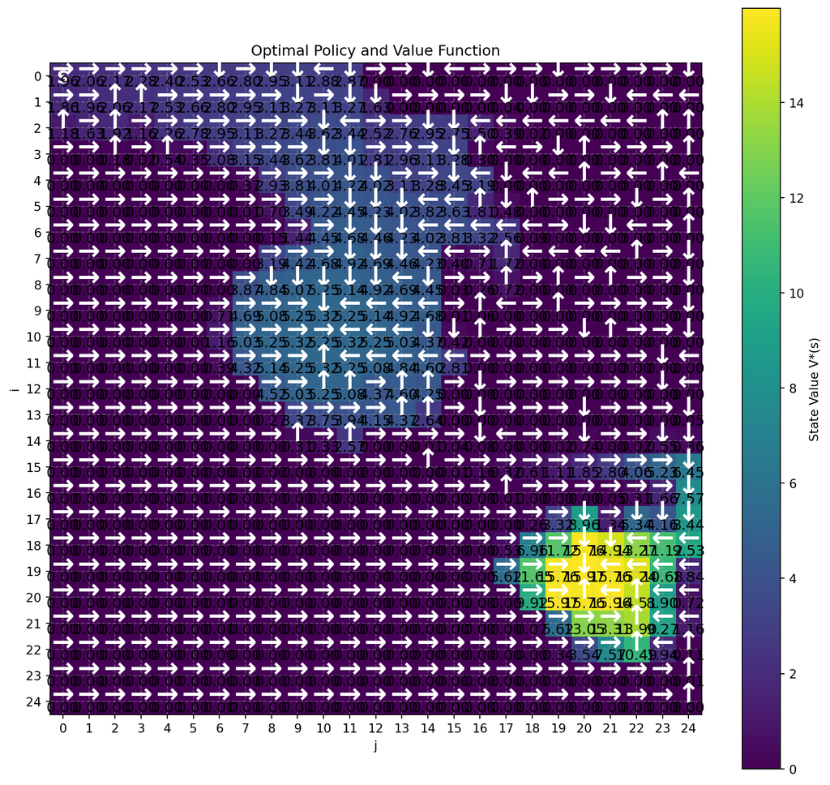

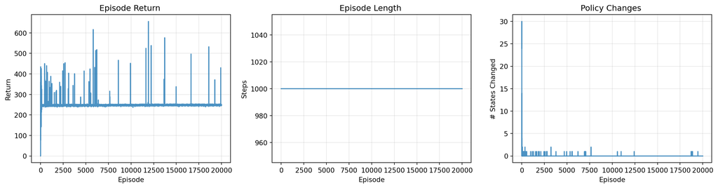

## 5 Part 4: Visualize Trained Agents (Q Learning) Solve Environment

### 5.1 Expanded GridWorld Q-learning GIF:

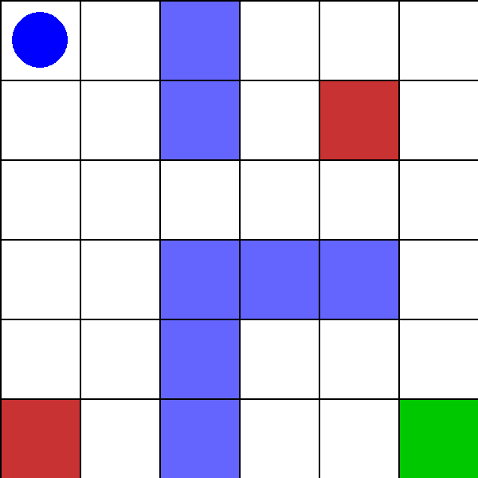

### 5.2 Simple GridWorld TD Q-learning GIF:

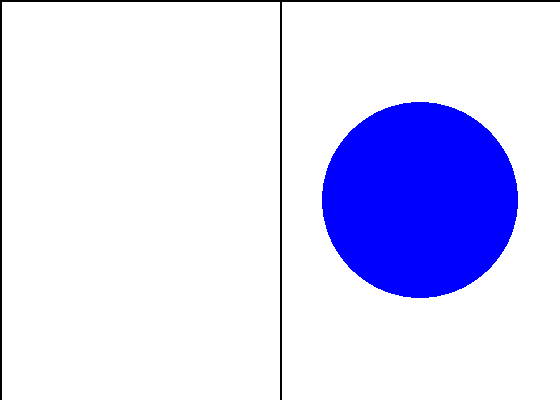

### 5.3 GeoSearch Q-learning GIF:

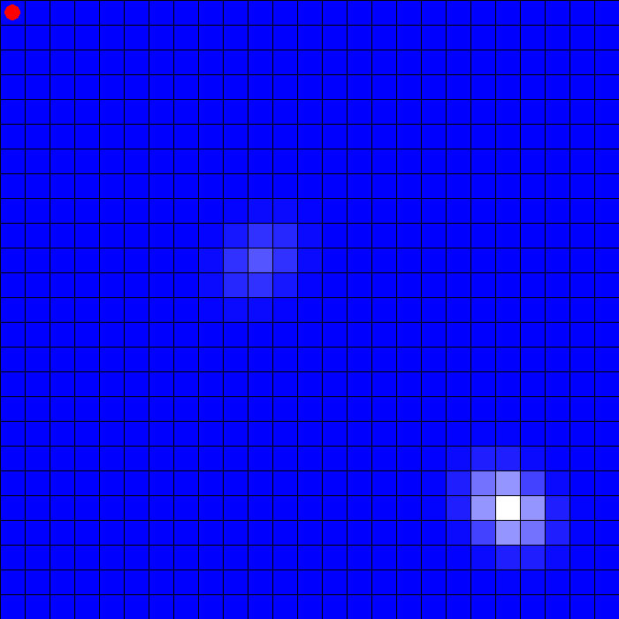

### 5.4 GeoSearch Monte Carlo GIF:

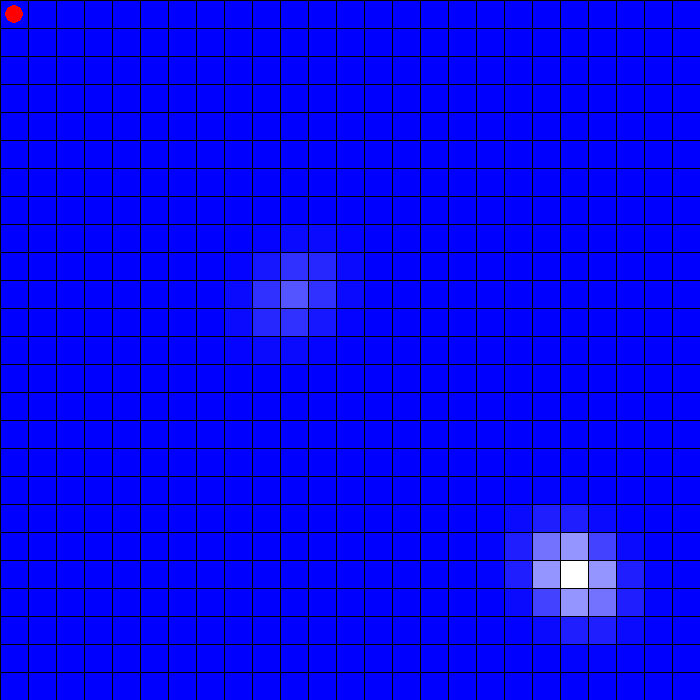